# STAT 302 Final Project

[Repo Link](https://github.com/stat-302-2026-spring/final-project-fmartin1312)

Folasade Martin

## Data Source

**Note**

[Link to data source](https://www.kaggle.com/datasets/muqaddasejaz/european-flights-dataset?resource=download)

I will be exploring a dataset, from Kaggle, that shows a detailed record of **air traffic activity across European airports** over a seven-year period (2016 - 2022). It captures Instrument Flight Rules (IFR) movements, including both arrivals and departures, as reported by Network Managers and Airport Operators.

## Why This Data

I chose this data set because I wanted to investigate changes in air traffic trends during two distinct periods: the **COVID-19 pandemic** and **Brexit**. I believe that these were the two events in the seven-year period that most affected European traveling habits. I find Brexit particularly interesting because British citizens began needing visas to enter EU countries. I hypothesize that this would have reduced overall departures and arrivals from British airports.

*But we will see if that is actually true in this presentation.*

# Pandemic Analysis

## Pandemic Impact on European Travel

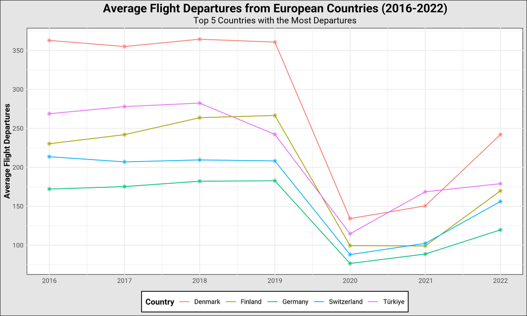

Figure 1

# Brexit Analysis

## Brexit’s Impact on British Travel Compared to EU Countries

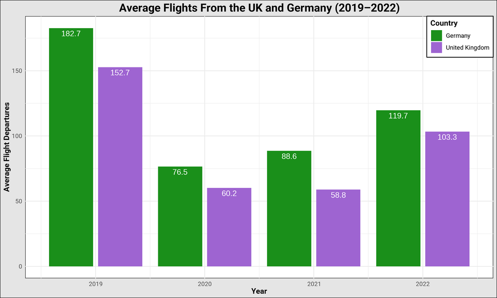

Figure 2